# Problem Set 07

Due Friday, April 7, 2017

Load necessary packages:

```r
library(ggplot2)
library(dplyr)
```

## Question: `nycflights13` data

```r
# Load all pacakges necessary
library(ggplot2)
library(dplyr)
library(knitr)

# Load all data sets in nycflights
library(nycflights13)
data(flights)
data(planes)
data(airlines)
data(weather)
data(airports)
```

You are a junior analyst in the airline industry, specifically working for Virgin America. You are tasked with calculating Virgin America’s total [available seat miles](https://en.wikipedia.org/wiki/Available_seat_miles) for all flights leaving each of the three New York Metropolitan area airports separately, and comparing these figures with those of ExpressJet Airlines Inc, a close rival to your company. Available seat miles are the fundamental units of production for a passenger-carrying airline and it is a measure of capacity. You are asked for two deliverables:

1. Present these results in
   - A well-formatted and easy to read table
   - A cleanly formatted visualization
2. Give a two sentence executive summary on the comparison in available seat miles between Virgin America and ExpressJet Airlines Inc for the three NYC airports.

Please heed the “tao of data analysis” [tips](https://rudeboybert.github.io/MATH116/notes.html#lec18_-_fri_324:_the_tao_of_data_analysis) before starting.

## Deliverable 1: Table

```r
# Clean up our workspace: Reduce both the flights and planes data sets to only
# those columns and rows we need.
flights_cleaned <- flights %>%
  filter(carrier == "VX" | carrier == "EV") %>%
  select(tailnum, carrier, distance, origin)

planes_cleaned <- planes %>%
  select(tailnum, seats)

# Now we join the two by the variable "tailnum". Note, when the variable we are
# joining along has the same name in both datasets, we don't need to do:
# by = c("tailnum" = "tailnum")
flights_planes_joined <- flights_cleaned %>%
  left_join(planes_cleaned, by = "tailnum")

results <- flights_planes_joined %>%
  # Now we can compute ASM:
  mutate(seat_miles = seats * distance) %>%
  # Since we want all 6 possible origin X carrier pairs, we group by
  # those variables and THEN summarize
  group_by(origin, carrier) %>%
  summarise(total_seat_miles = sum(seat_miles)) %>%
  # While not necessary, I decide to sort in descending order of ASM
  arrange(desc(total_seat_miles))

results
```

| origin | carrier | total_seat_miles |
| --- | --- | --- |
| JFK | VX | 1632349744 |
| EWR | EV | 1465958750 |
| EWR | VX | 664331034 |
| LGA | EV | 333516285 |
| JFK | EV | 17761240 |

## Deliverable 2: Visualization

Now when it comes to plotting, recall me email from Thursday, Oct 27 referencing how to plot a `geom_bar()` when you have an explicit variable you want to map to the `y` aesthetic. You need to tell `geom_bar()` to override its default behavior and use the `y=total_seat_miles` variable by setting `geom_bar(stat="identity")`. See the code for Problem Set 05 Discussion -> Q1.c) -> second plot comparing proportions for another example.

**Note**: We don’t forget the axes labels and title!

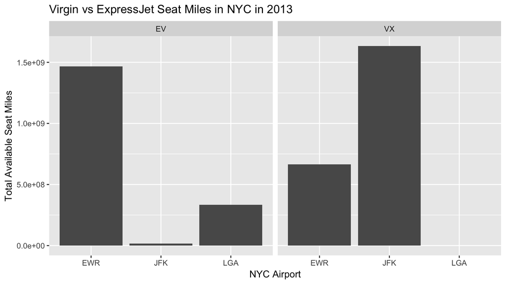

```r
ggplot(results, aes(x=origin, y=total_seat_miles)) +
  geom_bar(stat="identity") +
  facet_wrap(~carrier) +
  labs(x="NYC Airport", y="Total Available Seat Miles", title="Virgin vs ExpressJet Seat Miles in NYC in 2013")
```

My executive summary: Overall, we (as in Virgin America) have about the same capacity, but definitely spread out over different airports. We’ve got JFK covered, but definitely don’t have the capacity that ExpressJet does at Newark and La Guardia. So I suggest we target our marketing so that

- we promote our great number of options to people who tend to fly out of JFK.
- we start running ads that bad mouth ExpressJet to people who tend to fly out of Newark.

## Advanced

Once you get better at these things, you can write code super consisely. Not required for this class…

```r
flights %>%
  left_join(planes, by = "tailnum") %>%
  filter(carrier %in% c("VX", "EV")) %>%
  mutate(seat_miles = seats*distance) %>%
  group_by(origin, carrier) %>%
  summarise(total_seat_miles = sum(seat_miles)) %>%
  arrange(desc(total_seat_miles))
```

| origin | carrier | total_seat_miles |
| --- | --- | --- |
| JFK | VX | 1632349744 |
| EWR | EV | 1465958750 |
| EWR | VX | 664331034 |
| LGA | EV | 333516285 |
| JFK | EV | 17761240 |